# News Bias

The objective of this notebook is to analyze the subjective bias of news from the main Brazilian newspapers….

```r
options(warn=-1) # ignore warns
require(GGally, quietly = TRUE)
require(reshape2, quietly = TRUE)
require(tidyverse, quietly = TRUE, warn.conflicts = FALSE)
library(ggfortify)
library(cluster)
library(broom)
library(tidyverse)
library(plotly)
library(resample)
library(highcharter)
library(lubridate)
library(ggpubr)
library(here)
```

```r
carta_capital <- read_csv(here::here("data/carta_capital.csv")) %>% filter(arg >= 0, sen >= 0, val >= 0, pre >= 0, mod >= 0)
estadao <- read_csv(here::here("data/estadao.csv")) %>% filter(arg >= 0, sen >= 0, val >= 0, pre >= 0, mod >= 0)
folha <- read_csv(here::here("data/folha.csv")) %>% filter(arg >= 0, sen >= 0, val >= 0, pre >= 0, mod >= 0)
oantagonista <- read_csv(here::here("data/oantagonista.csv")) %>% filter(arg >= 0, sen >= 0, val >= 0, pre >= 0, mod >= 0)
oglobo <- read_csv(here::here("data/oglobo.csv")) %>% filter(arg >= 0, sen >= 0, val >= 0, pre >= 0, mod >= 0) %>% select(-X1, -text, -title, -sub_title, -author )
veja <- read_csv(here::here("data/veja.csv")) %>% filter(arg >= 0, sen >= 0, val >= 0, pre >= 0, mod >= 0)

news <- rbind(carta_capital, estadao, folha, oantagonista, oglobo, veja)
```

# Existe correlação entre as dimenssões de subjetividade?

### Análise das distribuição das dimenssões par a par

Ao analisar o plot par a par de cada dimenssão percebemos que todas as dimenssões possuem uma correlação positiva significante entre si, em especial `val x mod` e `pre x mod` possuem uma correlação mais forte.

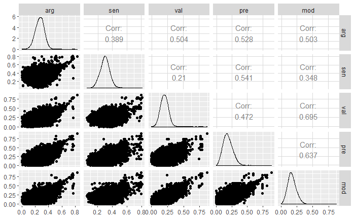

```r
news %>%
    select(arg, sen, val, pre, mod) %>%
    ggpairs()
```

# Qual a representatividade das dimenssões para o viés das notícias?

### Análise por redução de dimensionalidade

Para avaliar a representatividade de cada dimenssão vamos reduzilas por meio da técnica PCA e comparar a variância acumulada nos PCAs com a variância total existente nos dados originais. O gráfico abaixo exibe a relação dessas variâncias, com 3 PC’s quase 90% da informação original dos dados é representada.

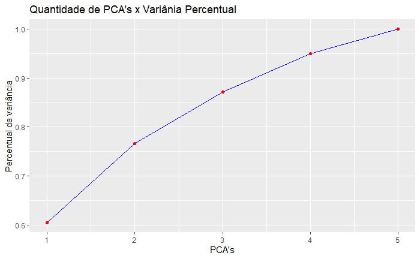

```r
pr.out <- prcomp(select(news, arg, sen, val, pre, mod), scale = FALSE)

tidy(pr.out, "pcs") %>%
    ggplot(aes(x = PC, y = cumulative)) +
    geom_line(color = "blue") +
    geom_point(color = "red") +
    labs(title = "Quantidade de PCA's x Variânia Percentual",
         x = "PCA's",
         y = "Percentual da variância")
```

### Interpretando os resultados

Os vetores mostram a relação entre PC1, PC2 e as variáveis. O alinhamento entre os vetores `arg` e o eixo PC1 indica que as variáveis geratrizes deste vetore variam bastante para pontos que estão mais a esquerda ou a direita do gráfico. Ou seja, o eixo PC1 `arg`, quanto mais a esquerda o ponto estiver menor são seus valores para `arg`, quanto mais a direita maior serão esses valores.

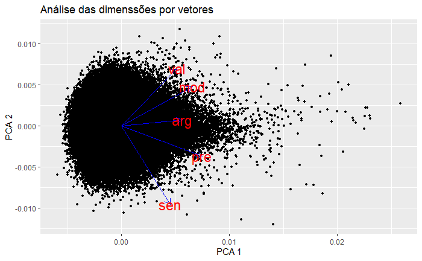

```r
autoplot(pr.out, data = news, size = 1,
         loadings = TRUE, loadings.colour = 'blue',
         loadings.label = TRUE,
         loadings.label.size = 6)  +
         labs(title = "Análise das dimenssões por vetores",
               x = "PCA 1",
               y = "PCA 2")
```

# É possível determinar grupos para classificar as notícias?

### Definindo os cluters

Pode-se definir o número de `clusters` do agrupamento por meio do calculo da distância quadrática entre o centro dos clusters, o centro dos dados e os dados. Aqui o centro dos dados é um ponto imaginário na média de todas as variáveis. O gráfico relaciona as variáveis `betweenss` e `totss`, essa proporção pode ser usada para definir um bom valor para o número de `clusters`. Quando a proporção para de crescer significativamente, aumentar os `clusters` não resulta numa melhor classificação. Neste caso, um bom valor para o número de `clusters` seria 4.

```r
set.seed(123)
explorando_clusters = tibble(clusters = 1:15) %>%
    group_by(clusters) %>%
    do(
        kmeans(select(news, arg, sen, val, pre, mod),
               centers = .$clusters,
               nstart = 20) %>% glance()
    )
```

```
|==========================================================================================================================================================|100% ~0 s remaining
```

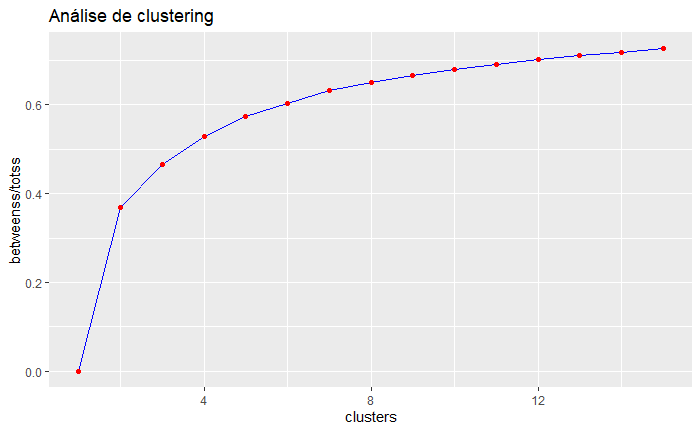

```r
explorando_clusters %>%
    ggplot(aes(x = clusters, y = betweenss / totss)) +
    geom_line(color = "blue") +
    geom_point(color = "red")  +
    labs(title = "Análise de clustering")
```

### Interpretando os clusters

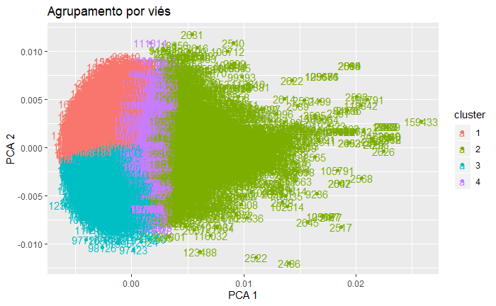

```r
set.seed(123)

n_clusters = 4

km = select(news, arg, sen, val, pre, mod) %>%
    kmeans(centers = n_clusters, nstart = 20)

dados.long = km %>%
    augment(news) %>%
    gather(key = "dimensão",
           value = "valor",
           arg, sen, val, pre, mod)

autoplot(km, data = news, label = TRUE)  +
    labs(title = "Agrupamento por viés",
         x = "PCA 1",
         y = "PCA 2")
```

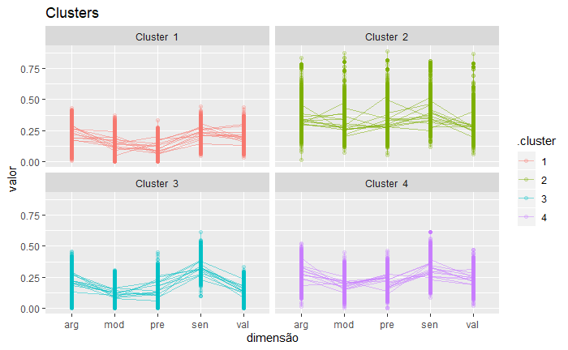

```r
dados.long %>%
    ggplot(aes(x = `dimensão`, y = valor, group = section, colour = .cluster)) +
    geom_point(alpha = 0.2) +
    geom_line(alpha = .5) +
    facet_wrap(~ paste("Cluster ",.cluster)) +
    labs(title = "Clusters")
```

# Qual o caderno mais subjetivo (considerando todas as notícias em um ano de coleta)?

Para estimar o caderno mais subjetivo ao longo do ano criamos o conceito de percentual de subjetividade definido como:

Analisando o plot do `percentual de subjetividade` por mês, percebemos que o caderno de política detém o maior viés durante o período eleitoral e após o término das eleições o cadernos apresenta queda de subjetividade. O caderno de esporte também apresenta queda de viés no periodo pós copa do mundo. Os outros cadernos mantém o mesmo percentual de subjetividade ao longo de 218 sem apresentar variações significativas.

```r
bias_section <- news %>%
  mutate(month = month(as_datetime(as.numeric(date)))) %>%
  group_by(month, section) %>%
  summarise(bias = (1 - (mean(arg) + mean(sen) + mean(val) + mean(pre) + mean(mod)) / 5) * 100)

highchart() %>%
  hc_title(text = "Bias distribution of each section per month") %>%
  hc_xAxis(categories = c("jan", "fev", "mar", "abr", "mai", "jun", "jul", "ago", "set", "out", "nov", "dez")) %>%
  hc_yAxis(title = list(text = "percentage of bias"),
           labels = list(format = "{value}%"), max = 80) %>%
  hc_tooltip(pointFormat = "{point.y}%") %>%
  hc_add_series(name = "diversos" , data = (bias_section %>% filter(section == "diversos"))$bias) %>%
  hc_add_series(name = "economia" , data = (bias_section %>% filter(section == "economia"))$bias) %>%
  hc_add_series(name = "educacao" , data = (bias_section %>% filter(section == "educacao"))$bias) %>%
  hc_add_series(name = "esporte" , data = (bias_section %>% filter(section == "esporte"))$bias) %>%
  hc_add_series(name = "internacional" , data = (bias_section %>% filter(section == "internacional"))$bias) %>%
  hc_add_series(name = "opiniao" , data = (bias_section %>% filter(section == "opiniao"))$bias) %>%
  hc_add_series(name = "politica" , data = (bias_section %>% filter(section == "politica"))$bias) %>%
  hc_add_series(name = "tecnologia" , data = (bias_section %>% filter(section == "tecnologia"))$bias)
```

[interactive chart not shown]

```r
NA
```

# Como é a distribuição das dimenssões de subjetividade ao longo do ano?

As dimenssões de subjetividade pouco variam no tempo, mas podemos notar que as dimenssões de `sentimento` e `argumentação` mantém um nível de viés menor que as demais ao longo de todo o ano, e não apresentarem correlação forte, de qualquer natureza, entre si.

```r
bias_month <- news %>%
  mutate(month = month(as_datetime(date))) %>%
  group_by(month) %>%
  summarise(
    arg = mean(arg),
    sen = mean(sen),
    val = mean(val),
    pre = mean(pre),
    mod = mean(mod)
  )

highchart() %>%
  hc_title(text = "Distribution of bias per month") %>%
  hc_xAxis(categories = c("jan", "fev", "mar", "abr", "mai", "jun", "jul", "ago", "set", "out", "nov", "dez")) %>%
  hc_yAxis(title = list(text = "bias")) %>%
  hc_tooltip(pointFormat = "{point.y}%") %>%
  hc_add_series(name = "arg" , data = (bias_month$arg)) %>%
  hc_add_series(name = "sen" , data = (bias_month$sen)) %>%
  hc_add_series(name = "val" , data = (bias_month$val)) %>%
  hc_add_series(name = "pre" , data = (bias_month$pre)) %>%
  hc_add_series(name = "mod" , data = (bias_month$mod))
```

[interactive chart not shown]

# Qual o jornal mais subjetivo (considerando todas as notícias em um ano de coleta)?

Plotando o `percentual de viés` x `mês` para cada jornal percebemos que diferente do esperado a `carta capital` apresentou o menor percentual de viés ao longo de 2018. O jornal mais enviesado foi o `oantagonista` com aproximandamente `10%` de viés a mais que a `carta capital` ao longo do ano.

```r
bias_carta_capita <- carta_capital %>%
  mutate(month = month(as_datetime(as.numeric(date)))) %>%
  group_by(month) %>%
  summarise(bias = (1 - (mean(arg) + mean(sen) + mean(val) + mean(pre) + mean(mod)) / 5) * 100)

bias_estadao <- estadao %>%
  mutate(month = month(as_datetime(as.numeric(date)))) %>%
  group_by(month) %>%
  summarise(bias = (1 - (mean(arg) + mean(sen) + mean(val) + mean(pre) + mean(mod)) / 5) * 100)

bias_folha <- folha %>%
  mutate(month = month(as_datetime(as.numeric(date)))) %>%
  group_by(month) %>%
  summarise(bias = (1 - (mean(arg) + mean(sen) + mean(val) + mean(pre) + mean(mod)) / 5) * 100)

bias_oantagonista <- oantagonista %>%
  mutate(month = month(as_datetime(as.numeric(date)))) %>%
  group_by(month) %>%
  summarise(bias = (1 - (mean(arg) + mean(sen) + mean(val) + mean(pre) + mean(mod)) / 5) * 100)

bias_oglobo <- oglobo %>%
  mutate(month = month(as_datetime(as.numeric(date)))) %>%
  group_by(month) %>%
  summarise(bias = (1 - (mean(arg) + mean(sen) + mean(val) + mean(pre) + mean(mod)) / 5) * 100)

bias_veja <- veja %>%
  mutate(month = month(as_datetime(as.numeric(date)))) %>%
  group_by(month) %>%
  summarise(bias = (1 - (mean(arg) + mean(sen) + mean(val) + mean(pre) + mean(mod)) / 5) * 100)

highchart() %>%
  hc_title(text = "Bias distribution of each mainstream per month") %>%
  hc_xAxis(categories = c("jan", "fev", "mar", "abr", "mai", "jun", "jul", "ago", "set", "out", "nov", "dez")) %>%
  hc_yAxis(title = list(text = "percentage of bias"),
           labels = list(format = "{value}%"), max = 85) %>%
  hc_tooltip(pointFormat = "{point.y}%") %>%
  hc_add_series(name = "carta_capital" , data = bias_carta_capita$bias) %>%
  hc_add_series(name = "estadao" , data = bias_estadao$bias) %>%
  hc_add_series(name = "folha" , data = bias_folha$bias) %>%
  hc_add_series(name = "oantagonista" , bias_oantagonista$bias) %>%
  hc_add_series(name = "oglobo" , data = bias_oglobo$bias) %>%
  hc_add_series(name = "veja" , data = bias_veja$bias)
```

[interactive chart not shown]

```r
library(boot)

repeticoes = 5000 # pelo menos 2000, mas mais não faz mal.
um_bootstrap <- function(x){
  bias = x %>% pull(bias)
  boot_x <- sample(bias,           # amostre dos dados
                   size = NROW(bias), # tamanho igual ao recebido
                   replace = TRUE) # aqui é o bootstrap
  return(mean(boot_x))
}

estadao <- estadao %>%
  mutate(bias = (1 - (arg + sen + val + pre + mod) / 5) * 100)

theta_c = mean(estadao$bias)

# A REAMOSTRAGEM
reamostragens = tibble(i = 1:repeticoes) %>%
  mutate(theta_c_s = map_dbl(i, ~ um_bootstrap(estadao)))

ci_estadao = reamostragens %>%
  mutate(conf.low = theta_c + quantile((theta_c_s - theta_c), .05),
         conf.high = theta_c + quantile((theta_c_s - theta_c), .95),
         statistic = theta_c)

folha <- folha %>%
  mutate(bias = (1 - (arg + sen + val + pre + mod) / 5) * 100)

theta_c = mean(folha$bias)

# A REAMOSTRAGEM
reamostragens = tibble(i = 1:repeticoes) %>%
  mutate(theta_c_s = map_dbl(i, ~ um_bootstrap(folha)))

ci_folha = reamostragens %>%
  mutate(conf.low = theta_c + quantile((theta_c_s - theta_c), .05),
         conf.high = theta_c + quantile((theta_c_s - theta_c), .95),
         statistic = theta_c)

oantagonista <- oantagonista %>%
  mutate(bias = (1 - (arg + sen + val + pre + mod) / 5) * 100)

theta_c = mean(oantagonista$bias)

# A REAMOSTRAGEM
reamostragens = tibble(i = 1:repeticoes) %>%
  mutate(theta_c_s = map_dbl(i, ~ um_bootstrap(oantagonista)))

ci_oantagonista = reamostragens %>%
  mutate(conf.low = theta_c + quantile((theta_c_s - theta_c), .05),
         conf.high = theta_c + quantile((theta_c_s - theta_c), .95),
         statistic = theta_c)

oglobo <- oglobo %>%
  mutate(bias = (1 - (arg + sen + val + pre + mod) / 5) * 100)

theta_c = mean(oglobo$bias)

# A REAMOSTRAGEM
reamostragens = tibble(i = 1:repeticoes) %>%
  mutate(theta_c_s = map_dbl(i, ~ um_bootstrap(oglobo)))

ci_oglobo = reamostragens %>%
  mutate(conf.low = theta_c + quantile((theta_c_s - theta_c), .05),
         conf.high = theta_c + quantile((theta_c_s - theta_c), .95),
         statistic = theta_c)

veja <- veja %>%
  mutate(bias = (1 - (arg + sen + val + pre + mod) / 5) * 100)

theta_c = mean(veja$bias)

# A REAMOSTRAGEM
reamostragens = tibble(i = 1:repeticoes) %>%
  mutate(theta_c_s = map_dbl(i, ~ um_bootstrap(veja)))

ci_veja = reamostragens %>%
  mutate(conf.low = theta_c + quantile((theta_c_s - theta_c), .05),
         conf.high = theta_c + quantile((theta_c_s - theta_c), .95),
         statistic = theta_c)
```

[figure not shown]

```r
ci_amostragens <-bind_rows(
    "estadao" = ci_estadao,
    "folha" = ci_folha,
    "oantagonista" = ci_oantagonista,
    "veja" = ci_veja,
    .id = "ci")


ci_amostragens %>%
    ggplot(aes(
        x = "",
        y = statistic,
        ymin = conf.low,
        ymax = conf.high,
    )) + facet_grid(. ~ ci)+
    geom_pointrange() +
    geom_point(size = 3) +
    labs(x = "Código",
         y = "Proporção de novos artistas")
```